# test

# loading required data

```r
dpca1.bcs <- read.csv(here::here("testdata/dpca1_bcs.csv"))
g <- read.csv(here::here("testdata/dpca1_g.csv"))
aca3.bcs <- read.csv(here::here("testdata/aca3_bcs.csv"))
virus <- readRDS(here::here("testdata/b5virus.rds"))
dpca1seurat <- readRDS('D:/BRT/BRT/Data/xc1/DPCA1L1.rds')
```

**be careful**, the orig.ident of seurat must be *sample_region*

```r
dpca1seurat@meta.data$orig.ident <- "wqg1_dpca1"
```

the column of the output of match_pattern is *bc, counts*

```r
head(g)
```

|  | X | cell | counts |
| --- | --- | --- | --- |
| 1 | 1 | AAACCCAAGCCGAATG | 10 |
| 2 | 2 | AAACCCAAGGGACTGT | 61 |
| 3 | 3 | AAACCCAAGTGCAACG | 36 |
| 4 | 4 | AAACCCACAGCTATTG | 4 |
| 5 | 5 | AAACCCACAGTATGAA | 6 |
| 6 | 6 | AAACCCACAGTCGGTC | 10 |

```r
# dpca1@coldata <- left_update(dpca1@coldata)
```

to update the counts, we should rename the counts. **tva and g** is necessary for analysis, for g-tva linked plasmids, we should replicate the result of g and change the colname

```r
g <- rename(g,g = counts) %>%
  select(cell,g)
head(g)
```

|  | cell | g |
| --- | --- | --- |
| 1 | AAACCCAAGCCGAATG | 10 |
| 2 | AAACCCAAGGGACTGT | 61 |
| 3 | AAACCCAAGTGCAACG | 36 |
| 4 | AAACCCACAGCTATTG | 4 |
| 5 | AAACCCACAGTATGAA | 6 |
| 6 | AAACCCACAGTCGGTC | 10 |

```r
tva <- rename(g,tva = g)
head(tva)
```

|  | cell | tva |
| --- | --- | --- |
| 1 | AAACCCAAGCCGAATG | 10 |
| 2 | AAACCCAAGGGACTGT | 61 |
| 3 | AAACCCAAGTGCAACG | 36 |
| 4 | AAACCCACAGCTATTG | 4 |
| 5 | AAACCCACAGTATGAA | 6 |
| 6 | AAACCCACAGTCGGTC | 10 |

# construct obj

Now , we can construct a brtstaretr obj

```r
dpca1 <- brtStarter(dpca1.bcs,seuratobj = dpca1seurat,virus = virus,sample = "wqg1",region = "dpca1")
```

and update the tva and g counts into the coldata

```r
dpca1@coldata <- left_update(dpca1@coldata,g,by = "cell",treat.na = 0)
dpca1@coldata <- left_update(dpca1@coldata,tva,by = "cell",treat.na = 0)
```

# noise cutoff

First, we can preview the counts of rvcounts and g across each clusters The **counts of g in ODs** seems abnormal, we’d better avoid ODs while calculating the noise of g

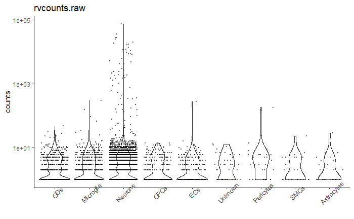

```r
brtVlnPlot(dpca1,feature = "rvcounts.raw")
```

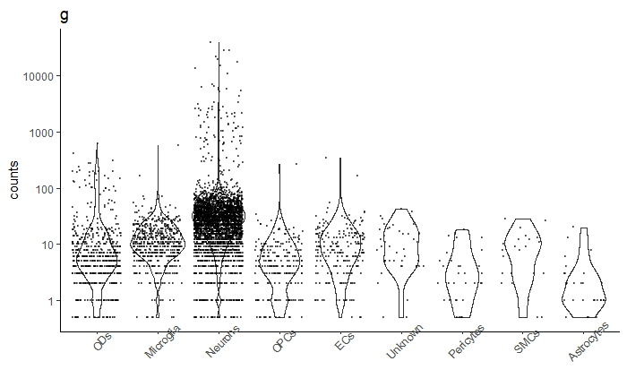

```r
brtVlnPlot(dpca1,feature = "g")
```

Next, we should set a threshold of barcodes. If we level background as NULL, then, all non-neurons clusters are treated as background, and cluster:Neurons is singnal. If the cluster name in your hand of Neurons is not Neurons, such as neurons, just change the parameter *signal* to neurons. Barcodes with counts below median + threshold * IQR of background counts is noise.

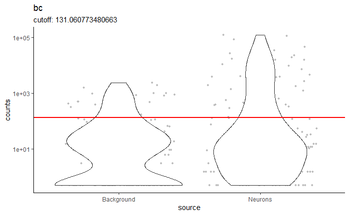

```r
brtPlotNoise(dpca1,"bc",background = NULL, threshold = 3)
```

**set noise bc with this function**

```r
dpca1 <- brtSetNoiseBc(dpca1,threshold = 3)
```

```
set 128/174 noise
```

# set cell state and unique bc

The unique probability of each barcode-carrying virus could be estimated according to the umi counts. For example, barcode *bcA* with P = 0.95 means that while injecting virus, the probablity that only one virus carried *bcA* is 0.95.

```r
dpca1 <- brtSetUniqueVirus(dpca1,P = 0.99)
```

```
estimate S: 100
set 45/46 unique virus
```

Next, we should set the state of cells (input/starter/naive) To do this, we should first estimated the threshold, as we disscused above, we’d better avoid ODs while calculating the threshold of g

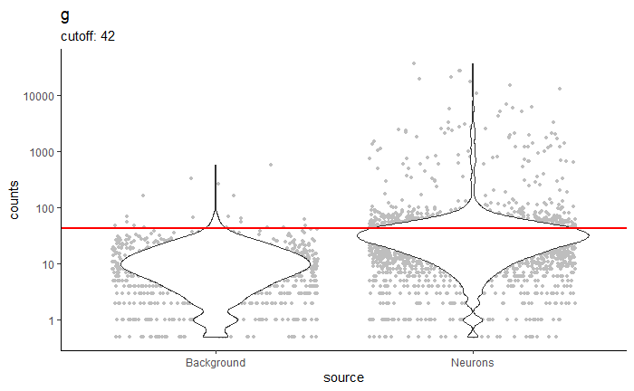

```r
brtPlotNoise(dpca1,feature = "g",background = setdiff(unique(dpca1@coldata$ident),"ODs"),threshold = 3)
```

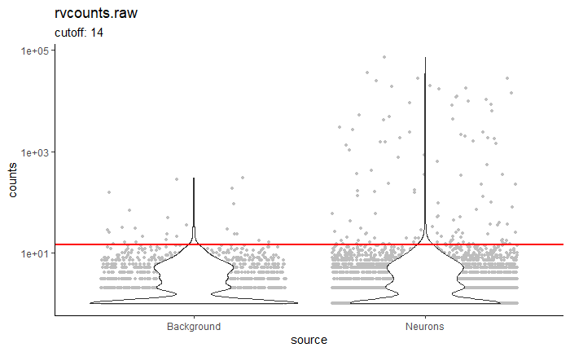

```r
brtPlotNoise(dpca1,feature = "rvcounts.raw",threshold = 3)
```

Now, we know the positive threshold of g/tva, but the negative threshold of tva/g is still unknown. This can be estimated by the probability of barcode positive cells(bcp). If under a threshold, bcp does’t increase with the counts of tva, then this threshold is appropriate. In this data, bcp is stable… just set the negative threshold as 42…

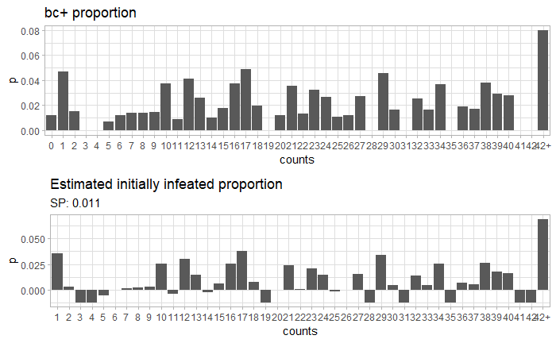

```r
brtPlotInfection(dpca1,tva.c = 42,rv.c = 14)
```

**set cell state here**

```r
dpca1 <- brtSetCellState(dpca1,starter = rvcounts.raw > 14 & g >42,input = rvcounts.raw > 14 & g < 42)
```

```
set 70 starters and 76 inputs
```

The last part is select unique barcode.

There are two standards for unique barcode.

1. for bc i,across cell 1-j, max(bc i) / sum(bc i) > P (default 0.8)

These selected bcs are dbcs(dominant bcs)

2. for dbc i, exist a cell j , dbc i / sum(cell j) > U (default 0.3)

These selected dbcs are ubcs (unique bcs)

```r
dpca1 <- brtSetUniqueBc(dpca1)
```

```
set 20 unique bcs across 17 cells
```

# construct unity

I do not have a seurat obj of aca3, so I change the region name of dpcall, and disguise it as aca3 obj

```r
aca3 <- dpca1
aca3@coldata$region <-"aca3"
aca3@coldata <- select(aca3@coldata,-rvcounts.unique,)
```

```r
unity <- brtUnity(list(dpca1),list(aca3))
unity
```

```
a brtUnity obj with  1  samples

single cell connections:
$wqg1
17 features across 142 samples

bulk connections:
0 features across 0 samples
```